# A Diffusion Analysis of Covid-19

Gabriela Soares

December 21, 2023

# Introduction

The emergence of COVID-19 started at the end of 2019 and by March of 2020, the World Health Organization (WHO) had already declared it as a pandemic. The following year was marked by uncertainty and global collaboration to try to mitigate the impact of the highly contagious virus. Implementing social distancing measures and utilizing face masks were the main strategies adopted when trying to diminish the spread of the coronavirus. These measures served as barriers, preventing the transmission of respiratory droplets and filtering exhalations from individuals who may be infected. In this study, I aim to make a diffusion analysis of COVID-19 using the *Zachary’s Karate Club Network* data from igraph. The data is used as representative of a circle of friendship and, in this hypothetical scenario, faces the 2020 pandemic.

# Data

The Zachary’s karate club network represents friendships between 34 members of a karate club at a US university in the 1970s.

# A Simple Model

The first model starts only with one seed and I assume that if the node was exposed to at least one other node with the virus, he/she will be infected. However, there is a latency of 0.5, which means that it will take the node 2 days to become infectious. Moreover, after 5 days of being infected, a node recovers and can no longer infect or become reinfected.

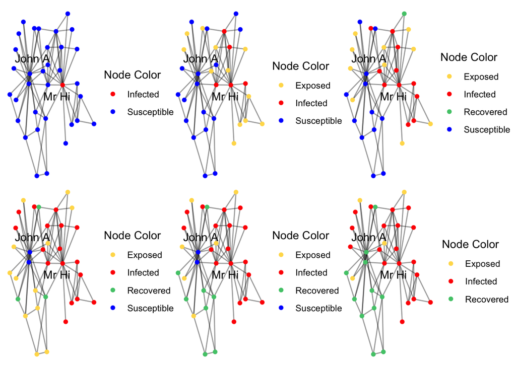

From this plot, we can see that the network is very connected and the virus spreads very quickly.

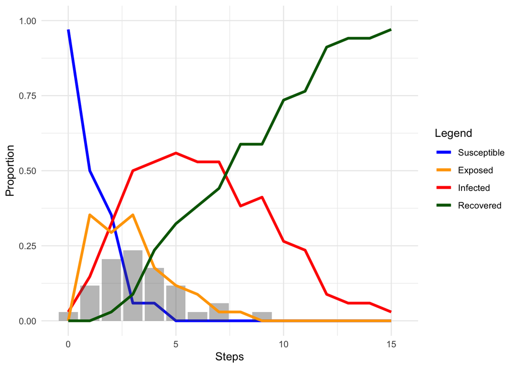

Indeed, here we can see where is the pick of the infections and the percentage of the network infected. The $R_0$ is 2.29, which is high, meaning that, on average, each infected node infects more than one other node. Thus, it is likely that there is going to be a pandemic.

# Mask Use

Now I am introducing the use of masks. This is one of the few actions we can do in order to reduce the transmission rate. I assume that first, one node got infected. Then, due to a lack of knowledge, 24 nodes were not wearing mask and, thus, only needed contact with one other node to be infected. However, 10 nodes were cautious and wore masks. They needed contact with at least 4 other infected nodes to contract the virus.

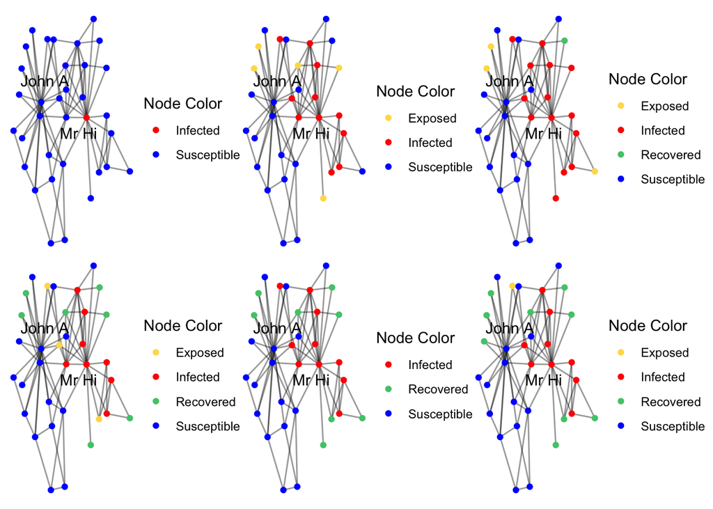

Now we can see how the use of masks affects the spread of the virus.

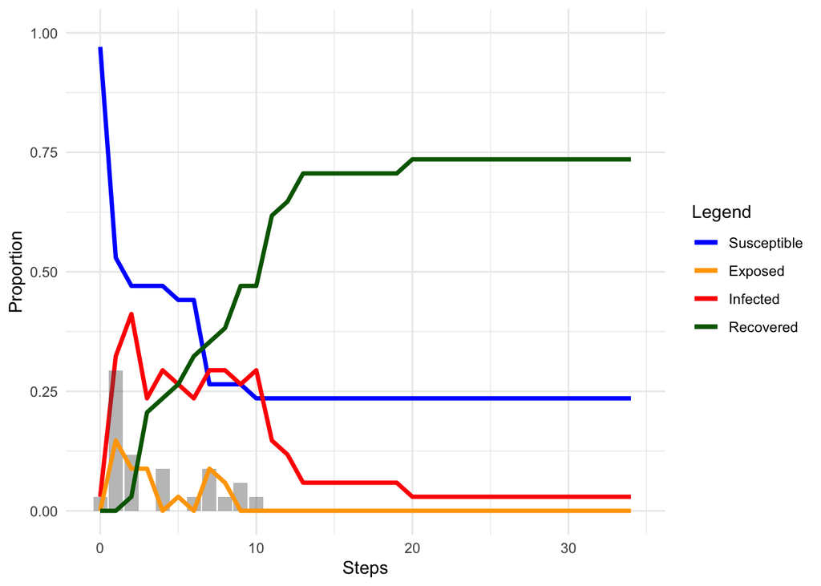

This graph is completely different from the one plotted above. In this case, the use of masks slows the diffusion, because people wearing masks need to be exposed to more people with COVID than people without. This generates a different diffusion pattern. For example, there might be some steps with no infection, periods of low levels of infection followed by periods of high levels of infection or even people that will not ever contract the virus.

# Seed Strategies

Once ideas and behaviours also spread like viruses I am going to analyse in this section where to seed the use of masks such that it has a rapid adoption. This is an interesting analysis because people may hesitate to wear a mask, for example, if they find it uncomfortable. However, the more they see people wearing it, the higher the social pressure they feel to use it too. In a university setting, one might think that the adoption of masks doesn’t happen as quickly because no one wants to be the first one to adopt their use or be one of the few who do so. Nevertheless, if I target the most popular individual, I can make the adoption of the mask quicker. Just like no one wants to be the first one to wear a mask, no one wants to be the only person not wearing one. To find this special node, I search for the node with higher eigenvector centrality - once he is jointly influencing more people. The node is John A with a degree of 0.36. Thus, by seeding the idea of using a mask on him, I get a higher likelihood that it will spread to other nodes more efficiently. First, I analyse a simple diffusion model, for a simpler and clearer visualization. The first graph is when the node seeded is assigned randomly while the second graph is when the seed is John A.

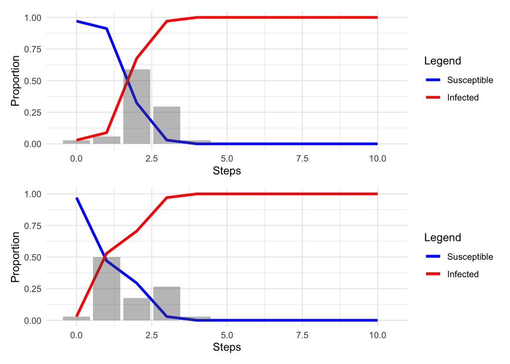

With these graphs, we can compare when a random node was the first one infected (either with COVID or with the *idea of using a mask*) with the situation where John A was the selected seed.

For a better analysis of formations of beliefs, I now use the DeGroot learning model to study how opinions about the use of masks would spread and evolve within the karate club. The model states that a network that is strongly connected and aperiodic will converge to a consensus of beliefs entered. Therefore, I check if the network is connected and aperiodic with the following code:

```r
is_connected(karate)
```

```
## [1] TRUE
```

```r
is_aperiodic(karate)
```

```
## [1] TRUE
```

We can see that the network converges to a consensus. I now create a vector of belief probabilities using binomial distribution with probability 0.25 and generate the distribution of beliefs:

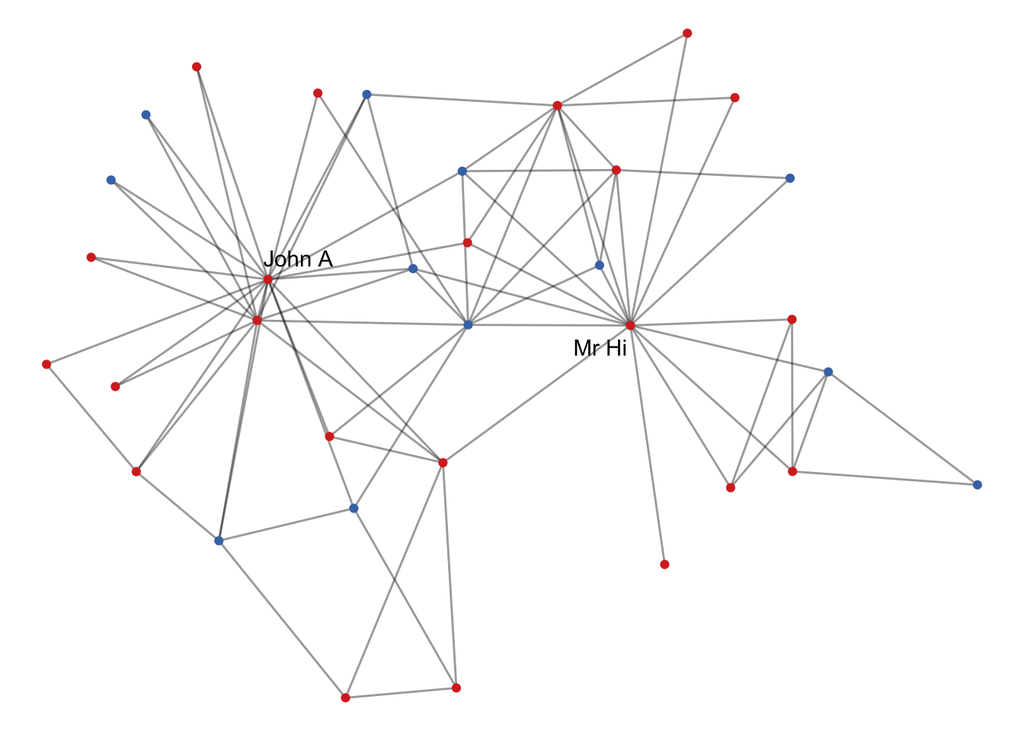

This graph of the network shows where the beliefs were distributed. The blue nodes are the ones that started believing that the use of masks was important.

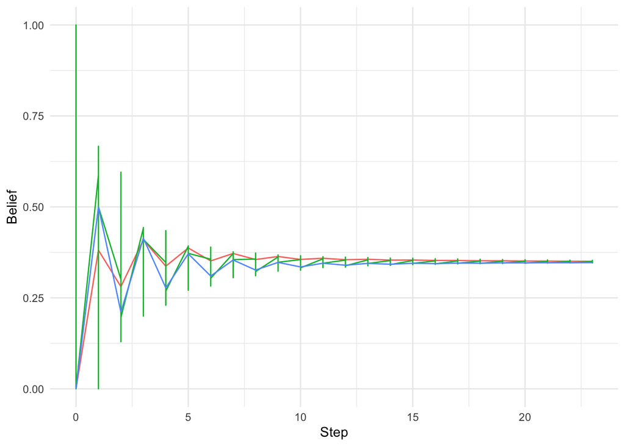

# Conclusion

Social networks play a pivotal role in the diffusion process, influencing how information, behaviours, or innovations spread within a community. In the first class of the Social Netowrk course, we were asked if central positions were associated with certain outcomes and from that day on we learned about the importance of positions, roles, ties, centrality and the network’s structure. In this final work, I studied the diffusion process aiming to better understand how this (unfortunately) famous disease spreads out in a group of people who would see each other often. I find it interesting because most people had hobbies - such as knitting clubs or ballet classes - and would meet regularly with a medium group of people when the pandemic started, so studying the *Zachary’s Karate Club* can be very relatable to a lot of people, including myself. Furthermore, studying it is important to see how the use of masks was, indeed, very important and able to prevent people from getting the virus.